# Lab 04 - Modelos (Solución)

```r
library(tidyverse)
library(modelr)
```

## Ejercicio 1

Utilizando la base de datos `diamonds`, visualiza la relación entre los siguientes pares de variables:

- `cut` y `price`
- `color` y `price`
- `clarity` y `price`

¿Encuentras un patrón atípico?

**Pista**: el color de menor calidad para un diamante es J (ligeramente amarillo), la peor claridad es I1 y el peor corte es Fair.

### Solución

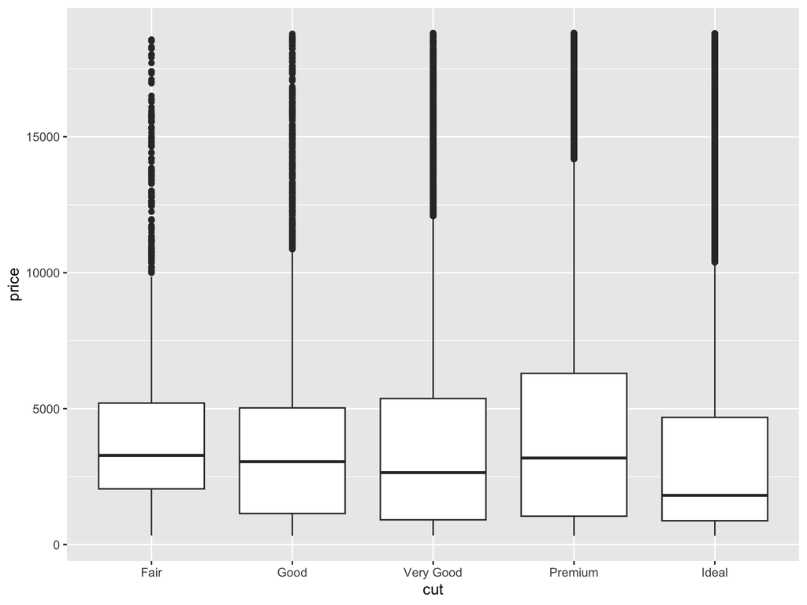

```r
ggplot(diamonds, aes(cut, price)) +
  geom_boxplot()
```

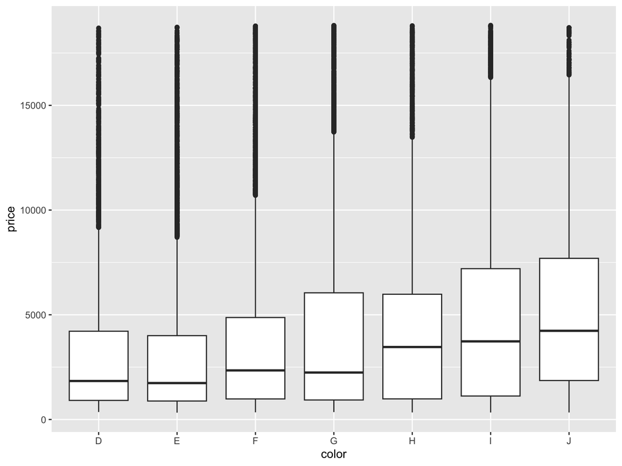

```r
ggplot(diamonds, aes(color, price)) +
  geom_boxplot()
```

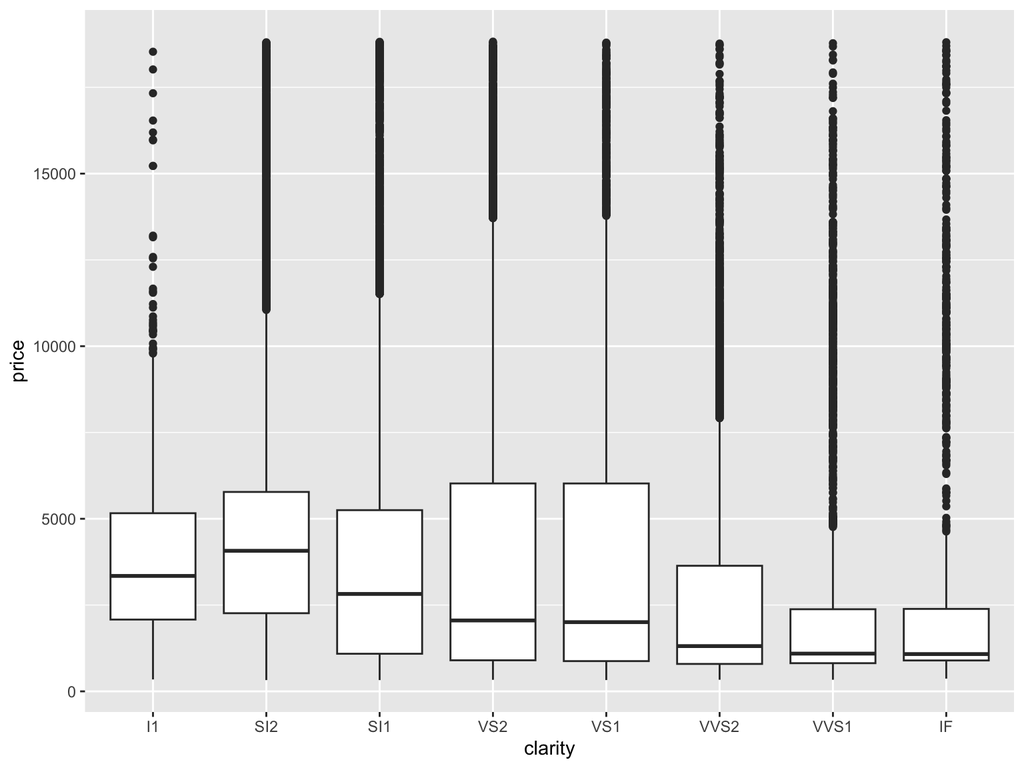

```r
ggplot(diamonds, aes(clarity, price)) +
  geom_boxplot()
```

Sí aparece un patrón que, a primera vista, resulta extraño: algunas categorías de peor calidad parecen tener precios más altos. En particular, no siempre observamos una relación monotónica simple entre calidad y precio.

La explicación es que el precio no depende solo de `cut`, `color` o `clarity`. Una variable muy importante es `carat`, y los diamantes más grandes tienden a ser mucho más caros. Por tanto, estas gráficas mezclan dos efectos: la calidad y el tamaño. La conclusión correcta no es que “los diamantes de peor calidad son mejores”, sino que con estas comparaciones bivariantes todavía hay confusión por variables omitidas, especialmente por el peso.

## Ejercicio 2

Ajusta un modelo lineal donde la variable predictora sea `carat` (el peso de los diamantes ) y la variable dependiente sea `price`. Obtén el valor de los coeficientes e interprétalos. ¿Qué conclusión extraes?

### Solución

```r
mod_diamond <- lm(price ~ carat, data = diamonds)
summary(mod_diamond)
```

```
##
## Call:
## lm(formula = price ~ carat, data = diamonds)
##
## Residuals:
##      Min       1Q   Median       3Q      Max
## -18585.3   -804.8    -18.9    537.4  12731.7
##
## Coefficients:
##             Estimate Std. Error t value Pr(>|t|)
## (Intercept) -2256.36      13.06  -172.8   <2e-16 ***
## carat        7756.43      14.07   551.4   <2e-16 ***
## ---
## Signif. codes:  0 '***' 0.001 '**' 0.01 '*' 0.05 '.' 0.1 ' ' 1
##
## Residual standard error: 1549 on 53938 degrees of freedom
## Multiple R-squared:  0.8493, Adjusted R-squared:  0.8493
## F-statistic: 3.041e+05 on 1 and 53938 DF,  p-value: < 2.2e-16
```

El modelo estimado es:

$$\widehat{price} = -2256.36 + 7756.43 \cdot carat$$

Interpretación de los coeficientes:

- El intercepto (`-2256.36`) es el precio predicho cuando `carat = 0`. No tiene una interpretación económica útil, porque un diamante con peso cero no es un caso realista.
- La pendiente (`7756.43`) indica que, según este modelo lineal, si el peso aumenta en 1 quilate, el precio esperado aumenta en unos 7756 dólares, en promedio.

La conclusión principal es que existe una relación positiva muy fuerte entre `carat` y `price`, pero eso no implica necesariamente que la relación sea perfectamente lineal en todo el rango. De hecho, al tratarse de una variable de precio, es razonable sospechar cierta curvatura y una variabilidad creciente a medida que aumenta el peso.

## Ejercicio 3

Visualiza las predicciones del modelo anterior, así como los residuos. Extrae conclusiones.

### Solución

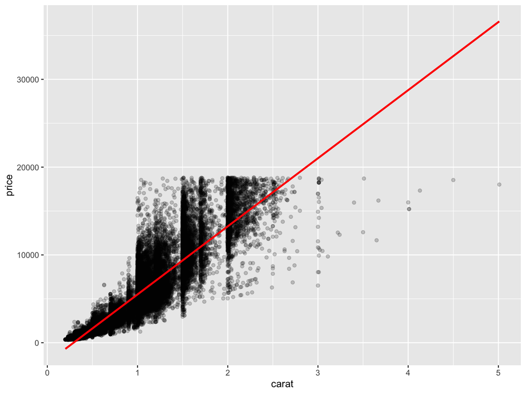

```r
grid <- diamonds %>%
  data_grid(carat = seq_range(carat, 40)) %>%
  add_predictions(mod_diamond, "price")

diamonds_res <- diamonds %>%
  add_predictions(mod_diamond, "pred") %>%
  add_residuals(mod_diamond, "resid")

ggplot(diamonds, aes(carat, price)) +
  geom_point(alpha = 0.2) +
  geom_line(data = grid, colour = "red", linewidth = 1)
```

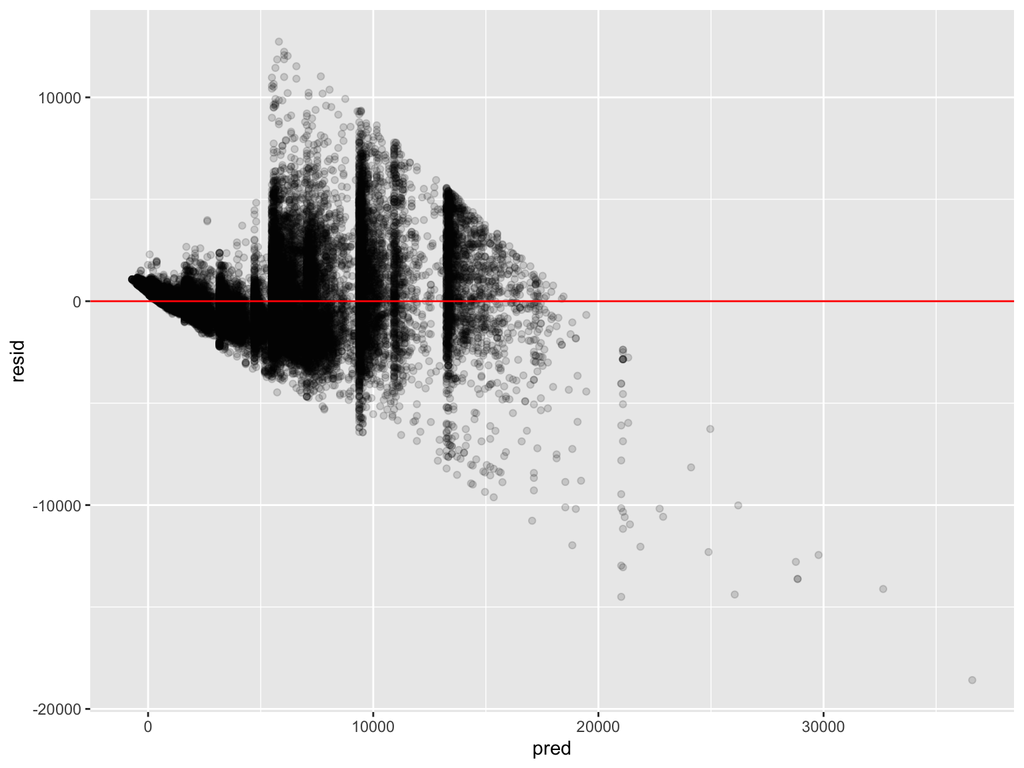

```r
ggplot(diamonds_res, aes(pred, resid)) +
  geom_point(alpha = 0.15) +
  geom_hline(yintercept = 0, colour = "red")
```

La recta recoge bien la tendencia general: a mayor `carat`, mayor precio. Sin embargo, la nube de puntos muestra que la relación no es completamente lineal y que la dispersión aumenta mucho para diamantes grandes.

En la gráfica de residuos no observamos una banda homogénea alrededor de cero. La variabilidad cambia con el nivel predicho y aparecen patrones sistemáticos, señal de que el modelo lineal simple en niveles no describe del todo bien la estructura de los datos. Esto sugiere dos problemas:

- heterocedasticidad: la varianza de los residuos no parece constante;
- posible no linealidad: la relación entre `carat` y `price` parece más bien curvada.

Por tanto, el modelo del ejercicio 2 es útil como primera aproximación, pero todavía es mejorable.

## Ejercicio 4

Crea un nuevo conjunto de datos llamado `diamonds2` donde elimines todos los diamantes de carat mayor que 2.5. Añade dos variables a este conjunto de datos llamandas `lcarat` y `lprice` que correspondan respectivamente a logaritmo en base dos de `carat` y `price`.

### Solución

```r
diamonds2 <- diamonds %>%
  filter(carat <= 2.5) %>%
  mutate(
    lprice = log2(price),
    lcarat = log2(carat)
  )
```

La construcción es correcta. El filtrado elimina observaciones extremas en tamaño, y la transformación logarítmica suele ayudar cuando la relación entre variables es multiplicativa o cuando la dispersión aumenta con el nivel de la variable.

## Ejercicio 5

Utilizando los datos creados en el ejercicio anterior, ajusta un modelo lineal donde la variable predictora sea `lcarat` y la variable dependiente sea `lprice`. Obtén el valor de los coeficientes e interprétalos. Según este modelo, que le sucede al precio de un diamante si multiplico por dos su `carat`.

### Solución

```r
mod_diamond_log <- lm(lprice ~ lcarat, data = diamonds2)
summary(mod_diamond_log)
```

```
##
## Call:
## lm(formula = lprice ~ lcarat, data = diamonds2)
##
## Residuals:
##      Min       1Q   Median       3Q      Max
## -1.96407 -0.24549 -0.00844  0.23930  1.93486
##
## Coefficients:
##              Estimate Std. Error t value Pr(>|t|)
## (Intercept) 12.193863   0.001969  6194.5   <2e-16 ***
## lcarat       1.681371   0.001936   868.5   <2e-16 ***
## ---
## Signif. codes:  0 '***' 0.001 '**' 0.01 '*' 0.05 '.' 0.1 ' ' 1
##
## Residual standard error: 0.3767 on 53812 degrees of freedom
## Multiple R-squared:  0.9334, Adjusted R-squared:  0.9334
## F-statistic: 7.542e+05 on 1 and 53812 DF,  p-value: < 2.2e-16
```

El modelo estimado es:

$$\widehat{\log_2(price)} = 12.1939 + 1.6814 \cdot \log_2(carat)$$

Equivalentemente,

$$\widehat{price} = 2^{12.1939} \cdot carat^{1.6814}$$

Interpretación:

- El coeficiente de `lcarat` es `1.6814`. En un modelo log-log, este coeficiente se interpreta como una elasticidad: un aumento del 1% en `carat` se asocia aproximadamente con un aumento del 1.68% en `price`.
- Como estamos usando logaritmos en base 2, doblar el valor de `carat` implica aumentar `lcarat` en una unidad.

Por tanto, si multiplicamos `carat` por 2, el precio esperado se multiplica por:

$$2^{1.6814} \approx 3.21$$

Es decir, según este modelo, al duplicar el peso del diamante, el precio esperado se multiplica aproximadamente por 3.2. Esta es una conclusión mucho más interpretable que la del modelo lineal en niveles.

## Ejercicio 6

Visualiza las predicciones del modelo anterior, así como los residuos. Extrae conclusiones. ¿Se ajusta este modelo mejor que el anterior a los datos?

### Solución

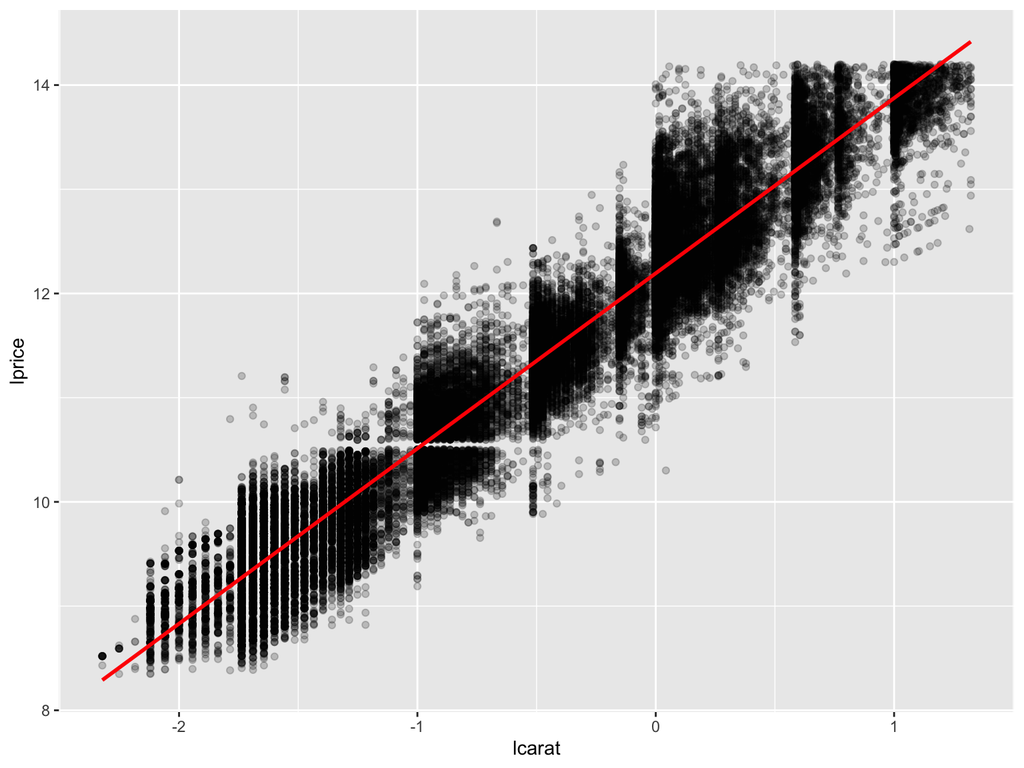

```r
grid_log <- diamonds2 %>%
  data_grid(lcarat) %>%
  add_predictions(mod_diamond_log, "lpred")

diamonds2_res <- diamonds2 %>%
  add_predictions(mod_diamond_log, "lpred") %>%
  add_residuals(mod_diamond_log, "lresid")

ggplot(diamonds2, aes(lcarat, lprice)) +
  geom_point(alpha = 0.2) +
  geom_line(data = grid_log, aes(y = lpred), colour = "red", linewidth = 1)
```

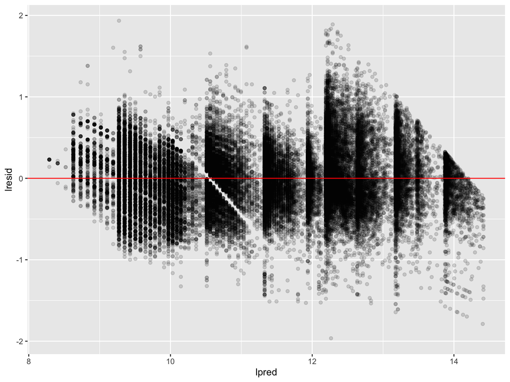

```r
ggplot(diamonds2_res, aes(lpred, lresid)) +
  geom_point(alpha = 0.15) +
  geom_hline(yintercept = 0, colour = "red")
```

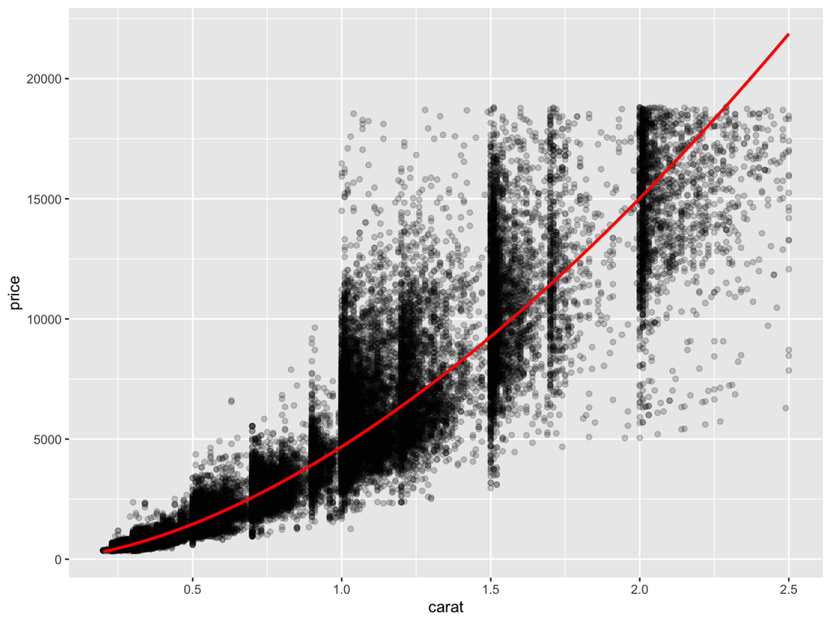

```r
grid_price <- diamonds2 %>%
  data_grid(carat) %>%
  mutate(lcarat = log2(carat)) %>%
  add_predictions(mod_diamond_log, "lprice") %>%
  mutate(price = 2^lprice)

ggplot(diamonds2, aes(carat, price)) +
  geom_point(alpha = 0.2) +
  geom_line(data = grid_price, colour = "red", linewidth = 1)
```

En escala logarítmica la relación entre tamaño y precio es bastante más lineal. Además, los residuos quedan más centrados y con una dispersión más homogénea que en el modelo lineal en niveles.

Esto indica que el modelo log-log se ajusta mejor a los datos por dos razones:

- capta mejor la curvatura de la relación entre `carat` y `price`;
- reduce el problema de heterocedasticidad.

Por tanto, sí, este modelo es preferible al del ejercicio 2 para describir la relación entre ambas variables.

## Ejercicio 7

Utilizando la base de datos `diamonds2`, visualiza la relación entre las siguientes variables y el residuo calculado en el ejercicio anterior. * `cut` * `color` * `clarity`

¿Qué conclusión extraes?

### Solución

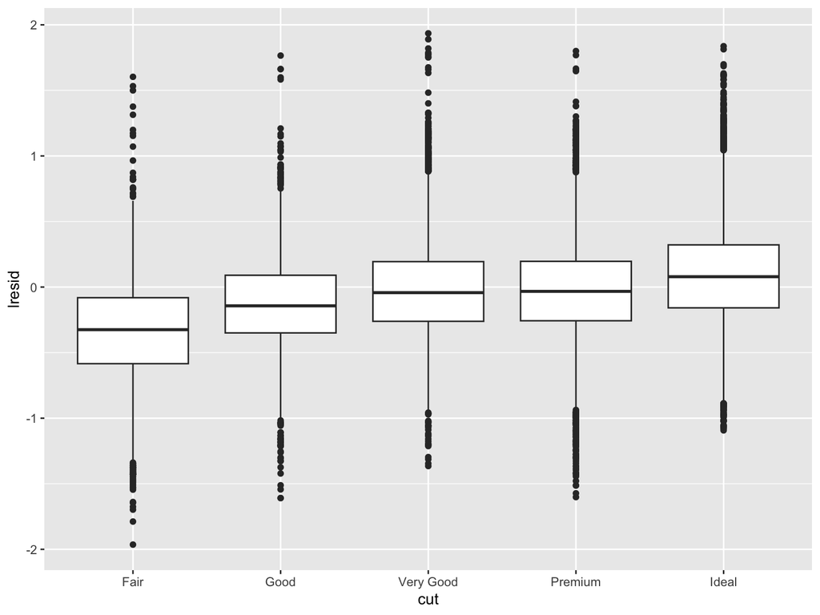

```r
ggplot(diamonds2_res, aes(cut, lresid)) +
  geom_boxplot()
```

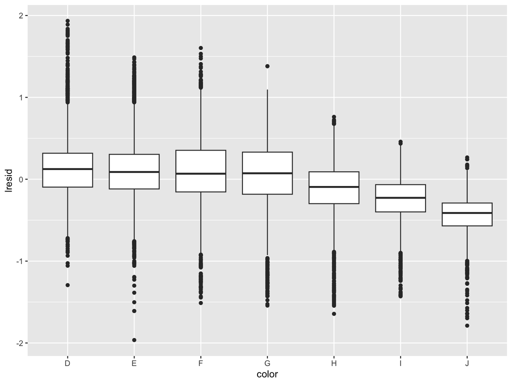

```r
ggplot(diamonds2_res, aes(color, lresid)) +
  geom_boxplot()
```

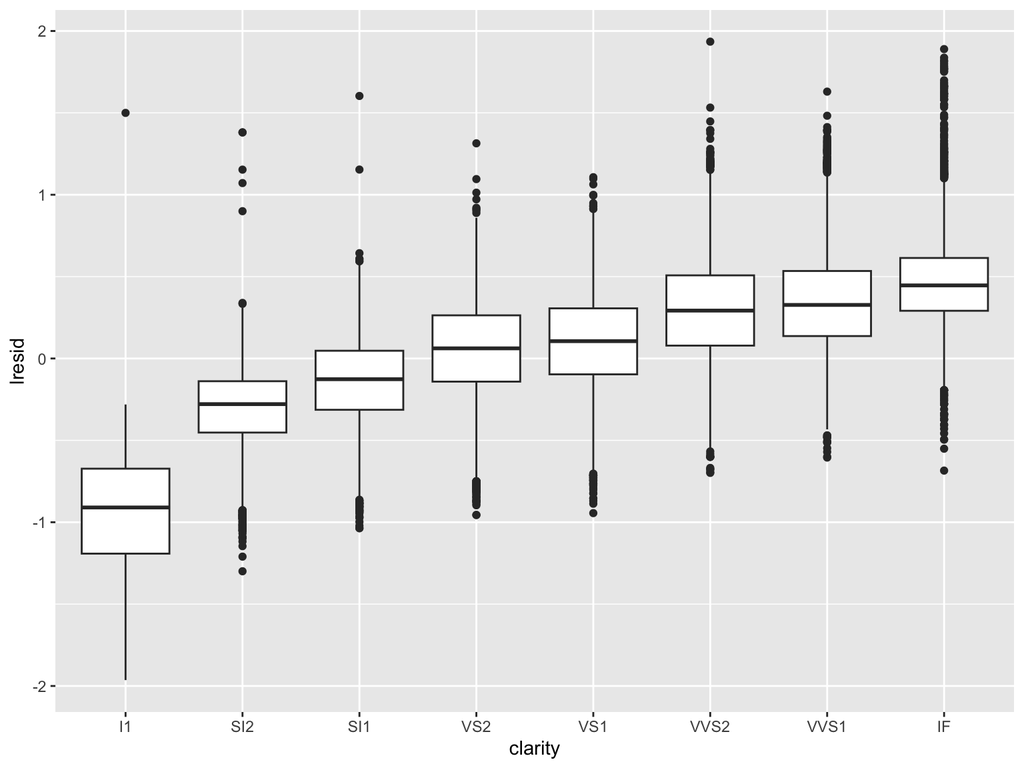

```r
ggplot(diamonds2_res, aes(clarity, lresid)) +
  geom_boxplot()
```

Los residuos no se distribuyen igual en todas las categorías. En particular:

- para `cut`, los diamantes `Ideal` tienden a tener residuos algo más positivos que los de peor corte;
- para `color`, las categorías de mejor color tienden a presentar residuos más altos que las peores;
- para `clarity`, la diferencia es todavía más clara: a mayor claridad, mayores residuos medios.

Esto significa que el modelo que solo usa `lcarat` sigue dejando información sistemática sin explicar. En promedio, manteniendo fijo el tamaño, los diamantes con mejor color, mejor corte y sobre todo mejor claridad tienden a valer más de lo que predice el modelo.

La conclusión es que `lcarat` explica una parte muy importante del precio, pero no toda. Para mejorar el modelo habría que incorporar variables de calidad como `cut`, `color` y `clarity`.

## Ejercicio 8

Explora los datos `sim3` de `modelr`. ¿De qué tipo son las variables `x1` y `x2`? ¿Y la `y`? Ajusta un modelo lineal con variable respuesta `y` y predictores `x1` y `x2` y visualiza sus predicciones.

Interpreta los coeficientes de este modelo.

### Solución

```r
glimpse(sim3)
```

```
## Rows: 120
## Columns: 5
## $ x1  <int> 1, 1, 1, 1, 1, 1, 1, 1, 1, 1, 1, 1, 2, 2, 2, 2, 2, 2, 2, 2, 2, 2, …
## $ x2  <fct> a, a, a, b, b, b, c, c, c, d, d, d, a, a, a, b, b, b, c, c, c, d, …
## $ rep <int> 1, 2, 3, 1, 2, 3, 1, 2, 3, 1, 2, 3, 1, 2, 3, 1, 2, 3, 1, 2, 3, 1, …
## $ y   <dbl> -0.5707363, 1.1841503, 2.2373204, 7.4366963, 8.5182934, 7.7239098,…
## $ sd  <dbl> 2, 2, 2, 2, 2, 2, 2, 2, 2, 2, 2, 2, 2, 2, 2, 2, 2, 2, 2, 2, 2, 2, …
```

`x1` es una variable numérica, `x2` es una variable categórica (factor) con varios niveles, e `y` es una variable numérica continua.

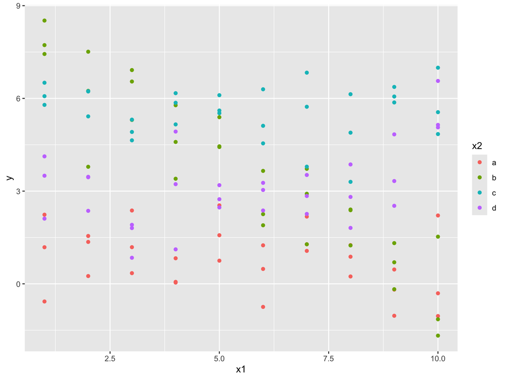

```r
ggplot(sim3, aes(x1, y, colour = x2)) +
  geom_point()
```

```r
mod1 <- lm(y ~ x1 + x2, data = sim3)

summary(mod1)
```

```
##
## Call:
## lm(formula = y ~ x1 + x2, data = sim3)
##
## Residuals:
##     Min      1Q  Median      3Q     Max
## -4.4674 -0.8524 -0.0729  0.7886  4.3005
##
## Coefficients:
##             Estimate Std. Error t value Pr(>|t|)
## (Intercept)  1.87167    0.38738   4.832 4.22e-06 ***
## x1          -0.19674    0.04871  -4.039 9.72e-05 ***
## x2b          2.88781    0.39571   7.298 4.07e-11 ***
## x2c          4.80574    0.39571  12.145  < 2e-16 ***
## x2d          2.35959    0.39571   5.963 2.79e-08 ***
## ---
## Signif. codes:  0 '***' 0.001 '**' 0.01 '*' 0.05 '.' 0.1 ' ' 1
##
## Residual standard error: 1.533 on 115 degrees of freedom
## Multiple R-squared:  0.5911, Adjusted R-squared:  0.5768
## F-statistic: 41.55 on 4 and 115 DF,  p-value: < 2.2e-16
```

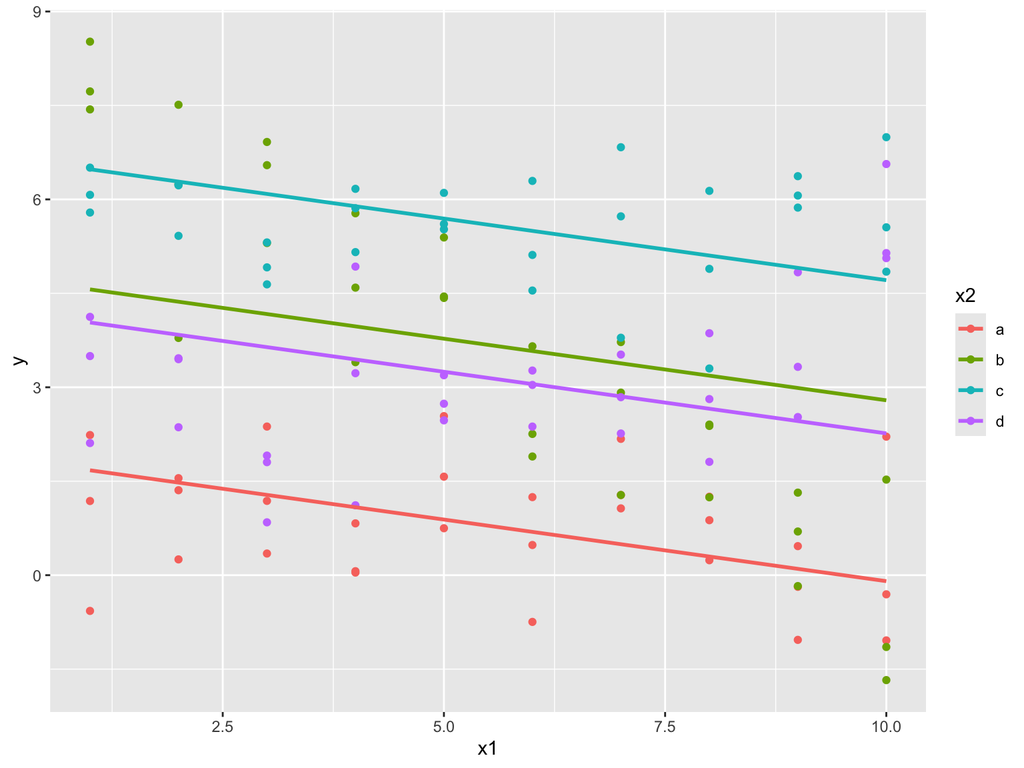

```r
grid <- sim3 %>%
  data_grid(x1, x2) %>%
  add_predictions(mod1)

ggplot(sim3, aes(x1, y, colour = x2)) +
  geom_point() +
  geom_line(data = grid, aes(y = pred), linewidth = 1)
```

El modelo es:

$$y = \beta_0 + \beta_1 x_1 + \beta_2 I(x_2=b) + \beta_3 I(x_2=c) +
\beta_4 I(x_2=d) + u$$

Si tomamos como categoría de referencia el nivel `a` de `x2`, la interpretación es:

- `\beta_0`: valor esperado de `y` cuando `x1 = 0` y `x2 = a`;
- `\beta_1`: cambio esperado en `y` cuando `x1` aumenta una unidad, manteniendo fija la categoría de `x2`;
- `\beta_2`, `\beta_3` y `\beta_4`: diferencia en el nivel esperado de `y` entre cada categoría (`b`, `c`, `d`) y la categoría de referencia `a`, manteniendo fijo `x1`.

Con las estimaciones obtenidas:

- la pendiente común de `x1` es aproximadamente `-0.197`, así que `y` disminuye ligeramente cuando `x1` aumenta;
- respecto a la categoría `a`, las categorías `b`, `c` y `d` desplazan la recta hacia arriba en unos `2.89`, `4.81` y `2.36` puntos, respectivamente.

Como el modelo no incluye interacción, todas las categorías comparten la misma pendiente y solo cambia el intercepto.

## Ejercicio 9

Con los datos anteriores, ajusta el siguiente modelo

$$y = \beta_0 + \beta_1 x_1 + \beta_2 x_2 + \beta_{12} x_1 x_2$$

en R este modelo se corresponde con la fórmula `y ~ x1 * x2`. Visualiza las predicciones del modelo, e interpreta sus coeficientes.

### Solución

```r
mod2 <- lm(y ~ x1 * x2, data = sim3)
summary(mod2)
```

```
##
## Call:
## lm(formula = y ~ x1 * x2, data = sim3)
##
## Residuals:
##      Min       1Q   Median       3Q      Max
## -2.87634 -0.67655  0.04837  0.69963  2.58607
##
## Coefficients:
##             Estimate Std. Error t value Pr(>|t|)
## (Intercept)  1.30124    0.40400   3.221  0.00167 **
## x1          -0.09302    0.06511  -1.429  0.15587
## x2b          7.06938    0.57134  12.373  < 2e-16 ***
## x2c          4.43090    0.57134   7.755 4.41e-12 ***
## x2d          0.83455    0.57134   1.461  0.14690
## x1:x2b      -0.76029    0.09208  -8.257 3.30e-13 ***
## x1:x2c       0.06815    0.09208   0.740  0.46076
## x1:x2d       0.27728    0.09208   3.011  0.00322 **
## ---
## Signif. codes:  0 '***' 0.001 '**' 0.01 '*' 0.05 '.' 0.1 ' ' 1
##
## Residual standard error: 1.024 on 112 degrees of freedom
## Multiple R-squared:  0.8221, Adjusted R-squared:  0.811
## F-statistic: 73.93 on 7 and 112 DF,  p-value: < 2.2e-16
```

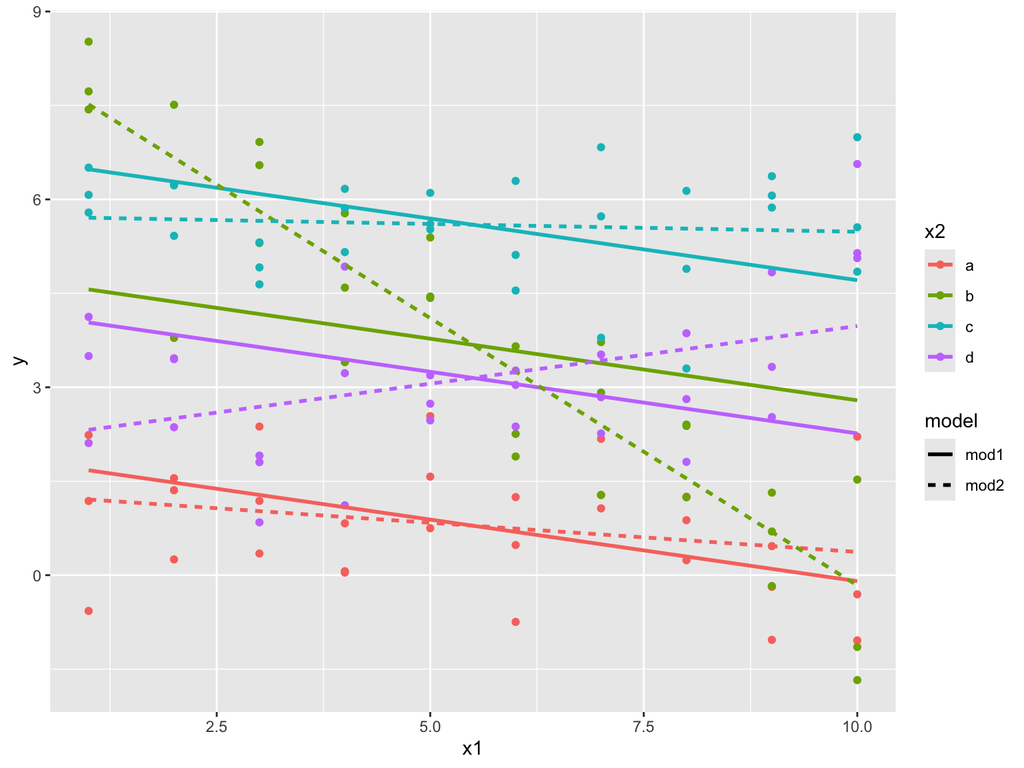

```r
grid2 <- sim3 %>%
  data_grid(x1, x2) %>%
  gather_predictions(mod1, mod2)

ggplot(sim3, aes(x1, y, colour = x2)) +
  geom_point() +
  geom_line(data = grid2, aes(y = pred, linetype = model), linewidth = 1)
```

Ahora permitimos que la pendiente de `x1` cambie según el nivel de `x2`. Tomando de nuevo `a` como categoría de referencia:

- `\beta_0` es el intercepto del grupo `a`;
- `\beta_1` es la pendiente de `x1` para el grupo `a`;
- `\beta_2`, `\beta_3`, `\beta_4` recogen cómo cambia el intercepto de los grupos `b`, `c` y `d` respecto a `a`;
- los términos de interacción (`x1:x2b`, `x1:x2c`, `x1:x2d`) indican cuánto cambia la pendiente de cada grupo respecto a la pendiente del grupo `a`.

Por ejemplo, con las estimaciones del modelo:

- para `x2 = a`, la pendiente es aproximadamente `-0.093`;
- para `x2 = b`, la pendiente es `-0.093 - 0.760 = -0.853`;
- para `x2 = c`, la pendiente es `-0.093 + 0.068 = -0.025`;
- para `x2 = d`, la pendiente es `-0.093 + 0.277 = 0.184`.

La interpretación sustantiva es clara: el efecto de `x1` sobre `y` no es el mismo para todas las categorías de `x2`. Por eso, frente al modelo del ejercicio 8, este modelo es más flexible y puede capturar rectas con pendientes distintas para cada grupo.